# Convolutional Neural Networks

## Project: Write an Algorithm for Landmark Classification

### Introduction

The project folder has the following structure:

- In the main directory you have this notebook, `cnn_from_scratch.ipynb`, that contains the instruction and some questions you will have to answer. Follow this notebook and complete the required sections in order.
- In the `src/` directory you have several source files. As instructed in this notebook, you will open and complete those files, then come back to this notebook to execute some tests that will verify what you have done. While these tests don't guarantee that your work is bug-free, they will help you finding the most obvious problems so you will be able to proceed to the next step with confidence.
- Sometimes you will need to restart the notebook. If you do so, remember to execute also the cells containing the code you have already completed starting from the top, before you move on.

In addition to implementing code, there will be questions that you must answer which relate to the project and your implementation. Each section where you will answer a question is preceded by a **'Question'** header. Carefully read each question and provide thorough answers in the following text boxes that begin with **'Answer:'**. Your project submission will be evaluated based on your answers to each of the questions and the implementation you provide.

[figure not shown]

> Code and Markdown cells can be executed using the **Shift + Enter** keyboard shortcut. Markdown cells can be edited by double-clicking the cell to enter edit mode.

The rubric contains *optional* "Stand Out Suggestions" for enhancing the project beyond the minimum requirements. If you decide to pursue the "Stand Out Suggestions", you should include the code in this Jupyter notebook.

### Designing and training a CNN from scratch

In this notebook, you will create a CNN that classifies landmarks. You must create your CNN *from scratch* (so, you can't use transfer learning *yet*!), and you must attain a test accuracy of at least 50%.

Although 50% may seem low at first glance, it seems more reasonable after realizing how difficult of a problem this is. Many times, an image that is taken at a landmark captures a fairly mundane image of an animal or plant, like in the following picture.

[figure not shown]

Just by looking at that image alone, would you have been able to guess that it was taken at the Haleakalā National Park in Hawaii?

An accuracy of 50% is significantly better than random guessing, which would provide an accuracy of just 2% (100% / 50 classes). In Step 2 of this notebook, you will have the opportunity to greatly improve accuracy by using transfer learning to create a CNN.

Experiment with different architectures, hyperparameters, training strategies, and trust your intuition. And, of course, have fun!

## Step 0: Setting up

[figure not shown]

The following cells make sure that your environment is setup correctly, download the data if you don't have it already, and also check that your GPU is available and ready to go. You have to execute them every time you restart your notebook.

```python
try:
    import torchinfo
    from torchinfo import summary
except:
    !pip install torchinfo
    import torchinfo
    from torchinfo import summary
```

```python
# Install requirements
!pip install -r requirements.txt | grep -v "already satisfied"
```

```
  WARNING: The script bokeh is installed in '/root/.local/bin' which is not on PATH.
  Consider adding this directory to PATH or, if you prefer to suppress this warning, use --no-warn-script-location.
  WARNING: The script tqdm is installed in '/root/.local/bin' which is not on PATH.
  Consider adding this directory to PATH or, if you prefer to suppress this warning, use --no-warn-script-location.
  WARNING: The scripts py.test and pytest are installed in '/root/.local/bin' which is not on PATH.
  Consider adding this directory to PATH or, if you prefer to suppress this warning, use --no-warn-script-location.
```

Important! After you have ran pip install, please restart the kernel using the **Kernel** menu

```python
from src.helpers import setup_env

# If running locally, this will download dataset (make sure you have at
# least 2 Gb of space on your hard drive)
setup_env()
```

```
GPU available
Dataset already downloaded. If you need to re-download, please delete the directory /data/DLND/C2/landmark_images
Reusing cached mean and std
```

```python
!ls -l /data/DLND/C2/landmark_images/train/* | wc -l
!ls -l /data/DLND/C2/landmark_images/test/* | wc -l
```

```
5145
1399
```

## Step 1: Data

[figure not shown]

In this and the following steps we are going to complete some code, and then execute some tests to make sure the code works as intended.

Open the file `src/data.py`. It contains a function called `get_data_loaders`. Read the function and complete all the parts marked by `YOUR CODE HERE`. Once you have finished, test that your implementation is correct by executing the following cell (see below for what to do if a test fails):

```python
!pytest -vv src/data.py -k data_loaders
```

```
============================= test session starts ==============================
platform linux -- Python 3.7.6, pytest-7.1.1, pluggy-1.2.0 -- /opt/conda/bin/python3.7
cachedir: .pytest_cache
rootdir: /workspace/home
collected 4 items / 1 deselected / 3 selected

src/data.py::test_data_loaders_keys PASSED                               [ 33%]
src/data.py::test_data_loaders_output_type PASSED                        [ 66%]
src/data.py::test_data_loaders_output_shape PASSED                       [100%]

======================= 3 passed, 1 deselected in 5.82s ========================
```

You should see something like:

```
src/data.py::test_data_loaders_keys PASSED                               [ 33%]
src/data.py::test_data_loaders_output_type PASSED                        [ 66%]
src/data.py::test_data_loaders_output_shape PASSED                       [100%]

======================= 3 passed, 1 deselected in 1.81s ========================
```

If all the tests are `PASSED`, you can move to the next section.

[figure not shown]

> **What to do if tests fail** When a test fails, `pytest` will mark it as `FAILED` as opposed to `PASSED`, and will print a lot of useful output, including a message that should tell you what the problem is. For example, this is the output of a failed test:

> ```
>    def test_data_loaders_keys(data_loaders):
>
>       assert set(data_loaders.keys()) == {"train", "valid", "test"}
> E       AssertionError: assert {'tes', 'train', 'valid'} == {'test', 'train', 'valid'}
> E         Extra items in the left set:
> E         'tes'
> E         Full diff:
> E         - {'test', 'train', 'valid'}
> E         + {'tes', 'train', 'valid'}
> E         ?                          +++++++
>
> src/data.py:171: AssertionError
> -------------- Captured stdout setup ----------------------------------------------
> Reusing cached mean and std for landmark_images
> Dataset mean: tensor([0.4638, 0.4725, 0.4687]), std: tensor([0.2699, 0.2706, 0.3018])
> =========== short test summary info ===============================================
> FAILED src/data.py::test_data_loaders_keys - AssertionError: The keys of the data_loaders dictionary should be train, valid and test
> ```

> In the `short test summary info` you can see a short description of the problem. In this case, the dictionary we are returning has the wrong keys. Going above a little, you can see that the test expects `{'test', 'train', 'valid'}` while we are returning `{'tes', 'train', 'valid'}` (there is a missing `t`). So we can go back to our function, fix that problem and test again.

> In other cases, you might get an error like:

> ```
>     def _conv_forward(self, input: Tensor, weight: Tensor, bias: Optional[Tensor]):
>         if self.padding_mode != 'zeros':
>             return F.conv2d(F.pad(input, self._reversed_padding_repeated_twice, mode=self.padding_mode),
>                             weight, bias, self.stride,
>                             _pair(0), self.dilation, self.groups)
>         return F.conv2d(input, weight, bias, self.stride,
>                       self.padding, self.dilation, self.groups)
> E       RuntimeError: Input type (torch.cuda.FloatTensor) and weight type (torch.FloatTensor) should be the same
>
> ../../../../miniconda3/envs/udacity_starter/lib/python3.7/site-packages/torch/nn/modules/conv.py:440: RuntimeError
> ```

> Looking at the stack trace you should be able to understand what it is going on. In this case, we forgot to add a `.cuda()` to some tensor. For example, the model is on the GPU, but the data aren't.

[figure not shown]

**Question:** Describe your chosen procedure for preprocessing the data.

- How does your code resize the images (by cropping, stretching, etc)? What size did you pick for the input tensor, and why?
- Did you decide to augment the dataset? If so, how (through translations, flips, rotations, etc)? If not, why not?

[figure not shown]

**Answer**: My code first resizes the image to 256 and then crops to 224. I picked 224 as the input size because it is the recommended input size for using pytorch's pre-trained models. I did decide to augment the dataset via RandAugment, a typical set of augmentations for natural images. I added this augmentation with the goal of improving my model's robustness, thus improving test accuracy.

### Visualize a Batch of Training Data

Go back to `src/data.py` and complete the function `visualize_one_batch` in all places with the `YOUR CODE HERE` marker. After you're done, execute the following cell and make sure the test `src/data.py::test_visualize_one_batch` is `PASSED`:

```python
!pytest -vv src/data.py -k visualize_one_batch
```

```
============================= test session starts ==============================
platform linux -- Python 3.7.6, pytest-7.1.1, pluggy-1.2.0 -- /opt/conda/bin/python3.7
cachedir: .pytest_cache
rootdir: /workspace/home
collected 4 items / 3 deselected / 1 selected

src/data.py::test_visualize_one_batch PASSED                             [100%]

======================= 1 passed, 3 deselected in 5.28s ========================
```

We can now use the code we just completed to get a batch of images from your train data loader and look at them.

Visualizing the output of your data loader is a great way to ensure that your data loading and preprocessing (including transforms such as rotations, translations, color transforms...) are working as expected.

```
Reusing cached mean and std
Dataset mean: tensor([0.4638, 0.4725, 0.4687]), std: tensor([0.2699, 0.2706, 0.3018])
Reusing cached mean and std
```

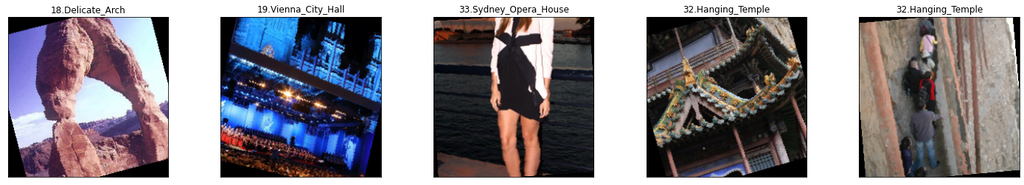

```python
%matplotlib inline
from src.data import visualize_one_batch, get_data_loaders

# use get_data_loaders to get the data_loaders dictionary. Use a batch_size
# of 5, a validation size of 0.01 and num_workers=-1 (all CPUs)
data_loaders = get_data_loaders() # YOUR CODE HERE

visualize_one_batch(data_loaders)
```

## Step 2: Define model

[figure not shown]

Open `src/model.py` and complete the `MyModel` class filling in all the `YOUR CODE HERE` sections. After you're done, execute the following test and make sure it passes:

```python
!pytest -vv src/model.py
```

```
============================= test session starts ==============================
platform linux -- Python 3.7.6, pytest-7.1.1, pluggy-1.2.0 -- /opt/conda/bin/python3.7
cachedir: .pytest_cache
rootdir: /workspace/home
collected 1 item

src/model.py::test_model_construction PASSED                             [100%]

============================== 1 passed in 8.93s ===============================
```

[figure not shown]

**Question**: Outline the steps you took to get to your final CNN architecture and your reasoning at each step.

[figure not shown]

**Answer:** I decided to use 5 convolutional layers so that my model could be sufficiently expressive. I used dropout layers to reduce my model's tendency to overfit the training data. I made my model output a 50-dimensional vector to match with the 50 available landmark classes.

## Step 3: define loss and optimizer

[figure not shown]

Open `src/optimization.py` and complete the `get_loss` function, then execute the test and make sure it passes:

```python
!pytest -vv src/optimization.py -k get_loss
```

```
============================= test session starts ==============================
platform linux -- Python 3.7.6, pytest-7.1.1, pluggy-1.2.0 -- /opt/conda/bin/python3.7
cachedir: .pytest_cache
rootdir: /workspace/home
collected 7 items / 6 deselected / 1 selected

src/optimization.py::test_get_loss PASSED                                [100%]

======================= 1 passed, 6 deselected in 1.91s ========================
```

Then, in the same file, complete the `get_optimizer` function then execute its tests, and make sure they all pass:

```python
!pytest -vv src/optimization.py -k get_optimizer
```

```
============================= test session starts ==============================
platform linux -- Python 3.7.6, pytest-7.1.1, pluggy-1.2.0 -- /opt/conda/bin/python3.7
cachedir: .pytest_cache
rootdir: /workspace/home
collected 7 items / 1 deselected / 6 selected

src/optimization.py::test_get_optimizer_type PASSED                      [ 16%]
src/optimization.py::test_get_optimizer_is_linked_with_model PASSED      [ 33%]
src/optimization.py::test_get_optimizer_returns_adam PASSED              [ 50%]
src/optimization.py::test_get_optimizer_sets_learning_rate PASSED        [ 66%]
src/optimization.py::test_get_optimizer_sets_momentum PASSED             [ 83%]
src/optimization.py::test_get_optimizer_sets_weight_decat PASSED         [100%]

======================= 6 passed, 1 deselected in 2.12s ========================
```

## Step 4: Train and Validate the Model

[figure not shown]

> Testing ML code is notoriously difficult. The tests in this section merely exercise the functions you are completing, so it will help you catching glaring problems but it won't guarantee that your training code is bug-free. If you see that your loss is not decreasing, for example, that's a sign of a bug or of a flawed model design. Use your judgement.

Open `src/train.py` and complete the `train_one_epoch` function, then run the tests:

```python
!pytest -vv src/train.py -k train_one_epoch
```

```
============================= test session starts ==============================
platform linux -- Python 3.7.6, pytest-7.1.1, pluggy-1.2.0 -- /opt/conda/bin/python3.7
cachedir: .pytest_cache
rootdir: /workspace/home
collected 4 items / 3 deselected / 1 selected

src/train.py::test_train_one_epoch PASSED                                [100%]

================== 1 passed, 3 deselected in 86.47s (0:01:26) ==================
```

Now complete the `valid` function, then run the tests:

```python
!pytest -vv src/train.py -k valid_one_epoch
```

```
============================= test session starts ==============================
platform linux -- Python 3.7.6, pytest-7.1.1, pluggy-1.2.0 -- /opt/conda/bin/python3.7
cachedir: .pytest_cache
rootdir: /workspace/home
collected 4 items / 3 deselected / 1 selected

src/train.py::test_valid_one_epoch PASSED                                [100%]

================== 1 passed, 3 deselected in 75.34s (0:01:15) ==================
```

Now complete the `optimize` function, then run the tests:

```python
!pytest -vv src/train.py -k optimize
```

```
============================= test session starts ==============================
platform linux -- Python 3.7.6, pytest-7.1.1, pluggy-1.2.0 -- /opt/conda/bin/python3.7
cachedir: .pytest_cache
rootdir: /workspace/home
collected 4 items / 3 deselected / 1 selected

src/train.py::test_optimize PASSED                                       [100%]

================= 1 passed, 3 deselected in 142.97s (0:02:22) ==================
```

Finally, complete the `test` function then run the tests:

```python
!pytest -vv src/train.py -k one_epoch_test
```

```
============================= test session starts ==============================
platform linux -- Python 3.7.6, pytest-7.1.1, pluggy-1.2.0 -- /opt/conda/bin/python3.7
cachedir: .pytest_cache
rootdir: /workspace/home
collected 4 items / 3 deselected / 1 selected

src/train.py::test_one_epoch_test PASSED                                 [100%]

================== 1 passed, 3 deselected in 74.33s (0:01:14) ==================
```

## Step 5: Putting everything together

[figure not shown]

Allright, good job getting here! Now it's time to see if all our hard work pays off. In the following cell we will train your model and validate it against the validation set.

Let's start by defining a few hyperparameters. Feel free to experiment with different values and try to optimize your model:

```python
#del MyModel
```

```python
batch_size = 32        # size of the minibatch for stochastic gradient descent (or Adam)
valid_size = 0.2       # fraction of the training data to reserve for validation
num_epochs = 5        # number of epochs for training
num_classes = 50       # number of classes. Do not change this
dropout = 0.2          # dropout for our model
learning_rate = 0.0003  # Learning rate for SGD (or Adam)
opt = 'Adam'            # optimizer. 'sgd' or 'adam'
weight_decay = 0.0     # regularization. Increase this to combat overfitting
```

```python
from src.model import MyModel
MyModel(num_classes=num_classes, dropout=dropout).test_model()
```

```
torch.Size([3, 3, 224, 224])
Output from model is of dimension: torch.Size([3, 50])
Number of Model Parameters : 14487890
Displaying Model Parameters summary:
 ==========================================================================================
Layer (type:depth-idx)                   Output Shape              Param #
==========================================================================================
MyModel                                  [3, 1000]                 --
├─Sequential: 1-1                        [3, 32, 112, 112]         --
│    └─Conv2d: 2-1                       [3, 32, 224, 224]         864
│    └─BatchNorm2d: 2-2                  [3, 32, 224, 224]         64
│    └─MaxPool2d: 2-3                    [3, 32, 112, 112]         --
│    └─ReLU: 2-4                         [3, 32, 112, 112]         --
│    └─Dropout2d: 2-5                    [3, 32, 112, 112]         --
├─Sequential: 1-2                        [3, 64, 56, 56]           --
│    └─Conv2d: 2-6                       [3, 64, 112, 112]         18,432
│    └─BatchNorm2d: 2-7                  [3, 64, 112, 112]         128
│    └─MaxPool2d: 2-8                    [3, 64, 56, 56]           --
│    └─ReLU: 2-9                         [3, 64, 56, 56]           --
│    └─Dropout2d: 2-10                   [3, 64, 56, 56]           --
├─Sequential: 1-3                        [3, 128, 28, 28]          --
│    └─Conv2d: 2-11                      [3, 128, 56, 56]          73,728
│    └─BatchNorm2d: 2-12                 [3, 128, 56, 56]          256
│    └─MaxPool2d: 2-13                   [3, 128, 28, 28]          --
│    └─ReLU: 2-14                        [3, 128, 28, 28]          --
│    └─Dropout2d: 2-15                   [3, 128, 28, 28]          --
├─Sequential: 1-4                        [3, 256, 14, 14]          --
│    └─Conv2d: 2-16                      [3, 256, 28, 28]          294,912
│    └─BatchNorm2d: 2-17                 [3, 256, 28, 28]          512
│    └─MaxPool2d: 2-18                   [3, 256, 14, 14]          --
│    └─ReLU: 2-19                        [3, 256, 14, 14]          --
│    └─Dropout2d: 2-20                   [3, 256, 14, 14]          --
├─Sequential: 1-5                        [3, 512, 7, 7]            --
│    └─Conv2d: 2-21                      [3, 512, 14, 14]          1,179,648
│    └─BatchNorm2d: 2-22                 [3, 512, 14, 14]          1,024
│    └─MaxPool2d: 2-23                   [3, 512, 7, 7]            --
│    └─ReLU: 2-24                        [3, 512, 7, 7]            --
│    └─Dropout2d: 2-25                   [3, 512, 7, 7]            --
├─Sequential: 1-6                        [3, 1000]                 --
│    └─Flatten: 2-26                     [3, 25088]                --
│    └─Linear: 2-27                      [3, 512]                  12,845,056
│    └─BatchNorm1d: 2-28                 [3, 512]                  1,024
│    └─ReLU: 2-29                        [3, 512]                  --
│    └─Dropout: 2-30                     [3, 512]                  --
│    └─Linear: 2-31                      [3, 128]                  65,536
│    └─BatchNorm1d: 2-32                 [3, 128]                  256
│    └─ReLU: 2-33                        [3, 128]                  --
│    └─Dropout: 2-34                     [3, 128]                  --
│    └─Linear: 2-35                      [3, 1000]                 129,000
==========================================================================================
Total params: 14,610,440
Trainable params: 14,610,440
Non-trainable params: 0
Total mult-adds (G): 2.94
==========================================================================================
Input size (MB): 1.81
Forward/backward pass size (MB): 149.38
Params size (MB): 58.44
Estimated Total Size (MB): 209.63
==========================================================================================
```

[output not shown]

```python
MyModel(num_classes=num_classes, dropout=dropout)
```

```
MyModel(
  (conv1): Sequential(
    (0): Conv2d(3, 32, kernel_size=(3, 3), stride=(1, 1), padding=(1, 1), bias=False)
    (1): BatchNorm2d(32, eps=1e-05, momentum=0.1, affine=True, track_running_stats=True)
    (2): MaxPool2d(kernel_size=2, stride=2, padding=0, dilation=1, ceil_mode=False)
    (3): ReLU(inplace=True)
    (4): Dropout2d(p=0.005, inplace=False)
  )
  (conv2): Sequential(
    (0): Conv2d(32, 64, kernel_size=(3, 3), stride=(1, 1), padding=(1, 1), bias=False)
    (1): BatchNorm2d(64, eps=1e-05, momentum=0.1, affine=True, track_running_stats=True)
    (2): MaxPool2d(kernel_size=2, stride=2, padding=0, dilation=1, ceil_mode=False)
    (3): ReLU(inplace=True)
    (4): Dropout2d(p=0.005, inplace=False)
  )
  (conv3): Sequential(
    (0): Conv2d(64, 128, kernel_size=(3, 3), stride=(1, 1), padding=(1, 1), bias=False)
    (1): BatchNorm2d(128, eps=1e-05, momentum=0.1, affine=True, track_running_stats=True)
    (2): MaxPool2d(kernel_size=2, stride=2, padding=0, dilation=1, ceil_mode=False)
    (3): ReLU(inplace=True)
    (4): Dropout2d(p=0.005, inplace=False)
  )
  (conv4): Sequential(
    (0): Conv2d(128, 256, kernel_size=(3, 3), stride=(1, 1), padding=(1, 1), bias=False)
    (1): BatchNorm2d(256, eps=1e-05, momentum=0.1, affine=True, track_running_stats=True)
    (2): MaxPool2d(kernel_size=2, stride=2, padding=0, dilation=1, ceil_mode=False)
    (3): ReLU(inplace=True)
    (4): Dropout2d(p=0.005, inplace=False)
  )
  (conv5): Sequential(
    (0): Conv2d(256, 512, kernel_size=(3, 3), stride=(1, 1), padding=(1, 1), bias=False)
    (1): BatchNorm2d(512, eps=1e-05, momentum=0.1, affine=True, track_running_stats=True)
    (2): MaxPool2d(kernel_size=2, stride=2, padding=0, dilation=1, ceil_mode=False)
    (3): ReLU(inplace=True)
    (4): Dropout2d(p=0.005, inplace=False)
  )
  (classifier): Sequential(
    (0): Flatten(start_dim=1, end_dim=-1)
    (1): Linear(in_features=25088, out_features=512, bias=False)
    (2): BatchNorm1d(512, eps=1e-05, momentum=0.1, affine=True, track_running_stats=True)
    (3): ReLU(inplace=True)
    (4): Dropout(p=0.2, inplace=False)
    (5): Linear(in_features=512, out_features=128, bias=False)
    (6): BatchNorm1d(128, eps=1e-05, momentum=0.1, affine=True, track_running_stats=True)
    (7): ReLU(inplace=True)
    (8): Dropout(p=0.2, inplace=False)
    (9): Linear(in_features=128, out_features=50, bias=True)
  )
)
```

```python
from src.data import get_data_loaders
loaders = get_data_loaders()
len(loaders['train'].dataset), len(loaders['valid'].dataset), len(loaders['test'].dataset), 0.8*4996,  0.2*4996
```

```
Reusing cached mean and std
Dataset mean: tensor([0.4638, 0.4725, 0.4687]), std: tensor([0.2699, 0.2706, 0.3018])
```

```
(4996, 4996, 1250, 3996.8, 999.2)
```

```python
from src.data import get_data_loaders
from src.train import optimize
from src.optimization import get_optimizer, get_loss
from src.model import MyModel

# get the data loaders using batch_size and valid_size defined in the previous
# cell
# HINT: do NOT copy/paste the values. Use the variables instead
data_loaders = get_data_loaders()# YOUR CODE HERE

# instance model MyModel with num_classes and drouput defined in the previous
# cell
model = MyModel(num_classes=num_classes, dropout=dropout) # YOUR CODE HERE

# Get the optimizer using get_optimizer and the model you just created, the learning rate,
# the optimizer and the weight decay specified in the previous cell
optimizer = get_optimizer(model, opt, learning_rate) # YOUR CODE HERE

# Get the loss using get_loss
loss = get_loss() # YOUR CODE HERE

optimize(
    data_loaders,
    model,
    optimizer,
    loss,
    n_epochs=num_epochs,
    save_path="checkpoints/best_val_loss.pt",
    interactive_tracking=False
)
```

```
Reusing cached mean and std
Dataset mean: tensor([0.4638, 0.4725, 0.4687]), std: tensor([0.2699, 0.2706, 0.3018])
```

```
Train Loss: 3.698434

\Train Accuracy:  9% (392/3996)
```

```
Validation Loss: 3.480715

\Validation Accuracy: 17% (170/1000)
Epoch: 1 	Training Loss: 3.698434 	Validation Loss: 3.480715
New minimum validation loss: 3.480715. Saving model ...
```

```
Train Loss: 3.369640

\Train Accuracy: 18% (733/3996)
```

```
Validation Loss: 3.218520

\Validation Accuracy: 23% (232/1000)
Epoch: 2 	Training Loss: 3.369640 	Validation Loss: 3.218520
New minimum validation loss: 3.218520. Saving model ...
```

```
Train Loss: 3.187062

\Train Accuracy: 22% (892/3996)
```

```
Validation Loss: 3.124792

\Validation Accuracy: 25% (250/1000)
Epoch: 3 	Training Loss: 3.187062 	Validation Loss: 3.124792
New minimum validation loss: 3.124792. Saving model ...
```

```
Train Loss: 3.018930

\Train Accuracy: 25% (1037/3996)
```

```
Validation Loss: 2.993698

\Validation Accuracy: 25% (252/1000)
Epoch: 4 	Training Loss: 3.018930 	Validation Loss: 2.993698
New minimum validation loss: 2.993698. Saving model ...
```

```
Train Loss: 2.881144

\Train Accuracy: 29% (1170/3996)
```

```
Validation Loss: 2.781110

\Validation Accuracy: 30% (302/1000)
Epoch: 5 	Training Loss: 2.881144 	Validation Loss: 2.781110
New minimum validation loss: 2.781110. Saving model ...
```

```python
!ls checkpoints/*
```

```
checkpoints/best_val_loss.pt
```

```python
!mv checkpoints/best_val_loss.pt checkpoints/best_val_loss_5_Epochs.pt
!ls checkpoints/*
```

```
checkpoints/best_val_loss_5_Epochs.pt
```

```python
num_epochs = 45
optimize(
    data_loaders,
    model,
    optimizer,
    loss,
    n_epochs=num_epochs,
    save_path="checkpoints/best_val_loss.pt",
    interactive_tracking=False
)
```

```
Train Loss: 2.742868

\Train Accuracy: 31% (1258/3996)
```

```
Validation Loss: 2.684292

\Validation Accuracy: 32% (329/1000)
Epoch: 1 	Training Loss: 2.742868 	Validation Loss: 2.684292
New minimum validation loss: 2.684292. Saving model ...
```

```
Train Loss: 2.626255

\Train Accuracy: 34% (1392/3996)
```

```
Validation Loss: 2.584520

\Validation Accuracy: 34% (347/1000)
Epoch: 2 	Training Loss: 2.626255 	Validation Loss: 2.584520
New minimum validation loss: 2.584520. Saving model ...
```

```
Train Loss: 2.526450

\Train Accuracy: 36% (1448/3996)
```

```
Validation Loss: 2.521221

\Validation Accuracy: 36% (365/1000)
Epoch: 3 	Training Loss: 2.526450 	Validation Loss: 2.521221
New minimum validation loss: 2.521221. Saving model ...
```

```
Train Loss: 2.438894

\Train Accuracy: 38% (1539/3996)
```

```
Validation Loss: 2.420297

\Validation Accuracy: 39% (391/1000)
Epoch: 4 	Training Loss: 2.438894 	Validation Loss: 2.420297
New minimum validation loss: 2.420297. Saving model ...
```

```
Train Loss: 2.332426

\Train Accuracy: 41% (1650/3996)
```

```
Validation Loss: 2.319685

\Validation Accuracy: 40% (402/1000)
Epoch: 5 	Training Loss: 2.332426 	Validation Loss: 2.319685
New minimum validation loss: 2.319685. Saving model ...
```

```
Train Loss: 2.250465

\Train Accuracy: 43% (1732/3996)
```

```
Validation Loss: 2.282161

\Validation Accuracy: 41% (416/1000)
Epoch: 6 	Training Loss: 2.250465 	Validation Loss: 2.282161
New minimum validation loss: 2.282161. Saving model ...
```

```
Train Loss: 2.187266

\Train Accuracy: 43% (1756/3996)
```

```
Validation Loss: 2.243670

\Validation Accuracy: 42% (423/1000)
Epoch: 7 	Training Loss: 2.187266 	Validation Loss: 2.243670
New minimum validation loss: 2.243670. Saving model ...
```

```
Train Loss: 2.099596

\Train Accuracy: 45% (1824/3996)
```

```
Validation Loss: 2.296258

\Validation Accuracy: 41% (416/1000)
Epoch: 8 	Training Loss: 2.099596 	Validation Loss: 2.296258
```

```
Train Loss: 2.019422

\Train Accuracy: 48% (1920/3996)
```

```
Validation Loss: 2.121100

\Validation Accuracy: 45% (451/1000)
Epoch: 9 	Training Loss: 2.019422 	Validation Loss: 2.121100
New minimum validation loss: 2.121100. Saving model ...
```

```
Train Loss: 1.965307

\Train Accuracy: 49% (1981/3996)
```

```
Validation Loss: 2.087466

\Validation Accuracy: 46% (466/1000)
Epoch: 10 	Training Loss: 1.965307 	Validation Loss: 2.087466
New minimum validation loss: 2.087466. Saving model ...
```

```
Train Loss: 1.891191

\Train Accuracy: 50% (2035/3996)
```

```
Validation Loss: 2.086393

\Validation Accuracy: 45% (457/1000)
Epoch: 11 	Training Loss: 1.891191 	Validation Loss: 2.086393
```

```
Train Loss: 1.810992

\Train Accuracy: 53% (2126/3996)
```

```
Validation Loss: 2.012840

\Validation Accuracy: 47% (479/1000)
Epoch: 12 	Training Loss: 1.810992 	Validation Loss: 2.012840
New minimum validation loss: 2.012840. Saving model ...
```

```
Train Loss: 1.795084

\Train Accuracy: 52% (2083/3996)
```

```
Validation Loss: 2.083967

\Validation Accuracy: 46% (463/1000)
Epoch: 13 	Training Loss: 1.795084 	Validation Loss: 2.083967
```

```
Train Loss: 1.725426

\Train Accuracy: 54% (2185/3996)
```

```
Validation Loss: 1.985912

\Validation Accuracy: 47% (472/1000)
Epoch: 14 	Training Loss: 1.725426 	Validation Loss: 1.985912
New minimum validation loss: 1.985912. Saving model ...
```

```
Train Loss: 1.698809

\Train Accuracy: 55% (2237/3996)
```

```
Validation Loss: 1.970700

\Validation Accuracy: 48% (487/1000)
Epoch: 15 	Training Loss: 1.698809 	Validation Loss: 1.970700
```

```
Train Loss: 1.620597

\Train Accuracy: 57% (2285/3996)
```

```
Validation Loss: 2.049209

\Validation Accuracy: 48% (486/1000)
Epoch: 16 	Training Loss: 1.620597 	Validation Loss: 2.049209
```

```
Train Loss: 1.575088

\Train Accuracy: 58% (2335/3996)
```

```
Validation Loss: 1.969225

\Validation Accuracy: 49% (491/1000)
Epoch: 17 	Training Loss: 1.575088 	Validation Loss: 1.969225
```

```
Train Loss: 1.523814

\Train Accuracy: 60% (2404/3996)
```

```
Validation Loss: 1.998337

\Validation Accuracy: 48% (482/1000)
Epoch: 18 	Training Loss: 1.523814 	Validation Loss: 1.998337
```

```
Train Loss: 1.461019

\Train Accuracy: 61% (2454/3996)
```

```
Validation Loss: 1.961005

\Validation Accuracy: 49% (493/1000)
Epoch: 19 	Training Loss: 1.461019 	Validation Loss: 1.961005
New minimum validation loss: 1.961005. Saving model ...
```

```
Train Loss: 1.418321

\Train Accuracy: 61% (2470/3996)
```

```
Validation Loss: 1.904361

\Validation Accuracy: 50% (503/1000)
Epoch: 20 	Training Loss: 1.418321 	Validation Loss: 1.904361
New minimum validation loss: 1.904361. Saving model ...
```

```
Train Loss: 1.403840

\Train Accuracy: 62% (2499/3996)
```

```
Validation Loss: 1.938693

\Validation Accuracy: 51% (510/1000)
Epoch: 21 	Training Loss: 1.403840 	Validation Loss: 1.938693
```

```
Train Loss: 1.346878

\Train Accuracy: 63% (2543/3996)
```

```
Validation Loss: 1.859984

\Validation Accuracy: 51% (511/1000)
Epoch: 22 	Training Loss: 1.346878 	Validation Loss: 1.859984
New minimum validation loss: 1.859984. Saving model ...
```

```
Train Loss: 1.274883

\Train Accuracy: 66% (2642/3996)
```

```
Validation Loss: 1.868816

\Validation Accuracy: 52% (522/1000)
Epoch: 23 	Training Loss: 1.274883 	Validation Loss: 1.868816
```

```
Train Loss: 1.268004

\Train Accuracy: 66% (2657/3996)
```

```
Validation Loss: 1.826454

\Validation Accuracy: 52% (525/1000)
Epoch: 24 	Training Loss: 1.268004 	Validation Loss: 1.826454
New minimum validation loss: 1.826454. Saving model ...
```

```
Train Loss: 1.209475

\Train Accuracy: 67% (2701/3996)
```

```
Validation Loss: 1.859701

\Validation Accuracy: 52% (528/1000)
Epoch: 25 	Training Loss: 1.209475 	Validation Loss: 1.859701
```

```
Train Loss: 1.162922

\Train Accuracy: 68% (2747/3996)
```

```
Validation Loss: 1.861945

\Validation Accuracy: 51% (510/1000)
Epoch: 26 	Training Loss: 1.162922 	Validation Loss: 1.861945
```

```
Train Loss: 1.098850

\Train Accuracy: 70% (2822/3996)
```

```
Validation Loss: 1.766242

\Validation Accuracy: 54% (540/1000)
Epoch: 27 	Training Loss: 1.098850 	Validation Loss: 1.766242
New minimum validation loss: 1.766242. Saving model ...
```

```
Train Loss: 1.100541

\Train Accuracy: 70% (2805/3996)
```

```
Validation Loss: 1.803079

\Validation Accuracy: 54% (543/1000)
Epoch: 28 	Training Loss: 1.100541 	Validation Loss: 1.803079
```

```
Train Loss: 1.060335

\Train Accuracy: 71% (2843/3996)
```

```
Validation Loss: 1.898120

\Validation Accuracy: 51% (515/1000)
Epoch: 29 	Training Loss: 1.060335 	Validation Loss: 1.898120
```

```
Train Loss: 1.028563

\Train Accuracy: 72% (2892/3996)
```

```
Validation Loss: 1.823588

\Validation Accuracy: 54% (543/1000)
Epoch: 30 	Training Loss: 1.028563 	Validation Loss: 1.823588
```

```
Train Loss: 0.992148

\Train Accuracy: 72% (2911/3996)
```

```
Validation Loss: 1.817223

\Validation Accuracy: 54% (546/1000)
Epoch: 31 	Training Loss: 0.992148 	Validation Loss: 1.817223
```

```
Train Loss: 0.956424

\Train Accuracy: 73% (2957/3996)
```

```
Validation Loss: 1.841118

\Validation Accuracy: 53% (537/1000)
Epoch: 32 	Training Loss: 0.956424 	Validation Loss: 1.841118
```

```
Train Loss: 0.921494

\Train Accuracy: 73% (2949/3996)
```

```
Validation Loss: 1.882274

\Validation Accuracy: 54% (543/1000)
Epoch: 33 	Training Loss: 0.921494 	Validation Loss: 1.882274
```

```
Train Loss: 0.883153

\Train Accuracy: 75% (3016/3996)
```

```
Validation Loss: 1.905947

\Validation Accuracy: 52% (528/1000)
Epoch: 34 	Training Loss: 0.883153 	Validation Loss: 1.905947
```

```
Train Loss: 0.871094

\Train Accuracy: 76% (3052/3996)
```

```
Validation Loss: 1.801394

\Validation Accuracy: 56% (565/1000)
Epoch: 35 	Training Loss: 0.871094 	Validation Loss: 1.801394
```

```
Train Loss: 0.826819

\Train Accuracy: 76% (3065/3996)
```

```
Validation Loss: 1.790118

\Validation Accuracy: 55% (553/1000)
Epoch: 36 	Training Loss: 0.826819 	Validation Loss: 1.790118
```

```
Train Loss: 0.820794

\Train Accuracy: 76% (3058/3996)
```

```
Validation Loss: 1.845498

\Validation Accuracy: 54% (543/1000)
Epoch: 37 	Training Loss: 0.820794 	Validation Loss: 1.845498
```

```
Train Loss: 0.780721

\Train Accuracy: 78% (3149/3996)
```

```
Validation Loss: 1.849103

\Validation Accuracy: 54% (546/1000)
Epoch: 38 	Training Loss: 0.780721 	Validation Loss: 1.849103
Epoch 00038: reducing learning rate of group 0 to 3.0000e-05.
```

```
Train Loss: 0.668005

\Train Accuracy: 82% (3279/3996)
```

```
Validation Loss: 1.684942

\Validation Accuracy: 57% (577/1000)
Epoch: 39 	Training Loss: 0.668005 	Validation Loss: 1.684942
New minimum validation loss: 1.684942. Saving model ...
```

```
Train Loss: 0.607305

\Train Accuracy: 83% (3356/3996)
```

```
Validation Loss: 1.679530

\Validation Accuracy: 58% (584/1000)
Epoch: 40 	Training Loss: 0.607305 	Validation Loss: 1.679530
```

```
Train Loss: 0.567559

\Train Accuracy: 85% (3399/3996)
```

```
Validation Loss: 1.654189

\Validation Accuracy: 58% (586/1000)
Epoch: 41 	Training Loss: 0.567559 	Validation Loss: 1.654189
New minimum validation loss: 1.654189. Saving model ...
```

```
Train Loss: 0.544703

\Train Accuracy: 86% (3457/3996)
```

```
Validation Loss: 1.654450

\Validation Accuracy: 59% (591/1000)
Epoch: 42 	Training Loss: 0.544703 	Validation Loss: 1.654450
```

```
Train Loss: 0.536751

\Train Accuracy: 86% (3448/3996)
```

```
Validation Loss: 1.637227

\Validation Accuracy: 59% (597/1000)
Epoch: 43 	Training Loss: 0.536751 	Validation Loss: 1.637227
New minimum validation loss: 1.637227. Saving model ...
```

```
Train Loss: 0.523363

\Train Accuracy: 86% (3461/3996)
```

```
Validation Loss: 1.666343

\Validation Accuracy: 59% (590/1000)
Epoch: 44 	Training Loss: 0.523363 	Validation Loss: 1.666343
```

```
Train Loss: 0.527870

\Train Accuracy: 86% (3438/3996)
```

```
Validation Loss: 1.640290

\Validation Accuracy: 59% (597/1000)
Epoch: 45 	Training Loss: 0.527870 	Validation Loss: 1.640290
```

## Step 6: testing against the Test Set

[figure not shown]

> only run this *after* you have completed hyperpameter optimization. Do not optimize hyperparameters by looking at the results on the test set, or you might overfit on the test set (bad, bad, bad)

Run the code cell below to try out your model on the test dataset of landmark images. Ensure that your test accuracy is greater than 50%.

```python
# load the model that got the best validation accuracy
from src.train import one_epoch_test
from src.model import MyModel
import torch

model = MyModel(num_classes=num_classes, dropout=dropout)

# YOUR CODE HERE: load the weights in 'checkpoints/best_val_loss.pt'
PATH = "checkpoints/best_val_loss.pt"
model.load_state_dict(torch.load(PATH))
# Run test
one_epoch_test(data_loaders['test'], model, loss)
```

```
Test Loss: 1.559178


Test Accuracy: 61% (764/1250)
```

```
1.559178349375725
```

## Step 7: Export using torchscript

[figure not shown]

Great job creating your CNN models! Now that you have put in all the hard work of creating accurate classifiers, let's export it so we can use it in our app.

But first, as usual, we need to complete some code!

Open `src/predictor.py` and fill up the missing code, then run the tests:

```python
!pytest -vv src/predictor.py
```

```
============================= test session starts ==============================
platform linux -- Python 3.7.6, pytest-7.1.1, pluggy-1.2.0 -- /opt/conda/bin/python3.7
cachedir: .pytest_cache
rootdir: /workspace/home
collected 1 item

src/predictor.py::test_model_construction PASSED                         [100%]

============================== 1 passed in 8.45s ===============================
```

Allright, now we are ready to export our model using our Predictor class:

```python
# NOTE: you might need to restart the notebook before running this step
# If you get an error about RuntimeError: Can't redefine method: forward on class
# restart your notebook then execute only this cell
from src.predictor import Predictor
from src.helpers import compute_mean_and_std
from src.model import MyModel
from src.data import get_data_loaders
import torch

data_loaders = get_data_loaders(batch_size=1)

# First let's get the class names from our data loaders
class_names = data_loaders["train"].dataset.classes

# Then let's move the model_transfer to the CPU
# (we don't need GPU for inference)
model = MyModel(num_classes=50, dropout=0.5).cpu()

# Let's make sure we use the right weights by loading the
# best weights we have found during training
# NOTE: remember to use map_location='cpu' so the weights
# are loaded on the CPU (and not the GPU)

# YOUR CODE HERE
model.load_state_dict(torch.load('checkpoints/best_val_loss.pt', map_location='cpu'))

# Let's wrap our model using the predictor class
mean, std = compute_mean_and_std()
predictor = Predictor(model, class_names, mean, std).cpu()

# Export using torch.jit.script
scripted_predictor = torch.jit.script(predictor) # YOUR CODE HERE

scripted_predictor.save("checkpoints/original_exported.pt")
```

```
Reusing cached mean and std
Dataset mean: tensor([0.4638, 0.4725, 0.4687]), std: tensor([0.2699, 0.2706, 0.3018])
Reusing cached mean and std
```

Now let's make sure the exported model has the same performance as the original one, by reloading it and testing it. The Predictor class takes different inputs than the non-wrapped model, so we have to use a specific test loop:

```python
import torch

# Load using torch.jit.load
model_reloaded =  torch.jit.load("checkpoints/original_exported.pt")# YOUR CODE HERE
```

```python
from src.predictor import predictor_test

pred, truth = predictor_test(data_loaders['test'], model_reloaded)
```

```
Accuracy: 0.5592
```

Finally, let's have a look at the confusion matrix of the model we are going to use in production:

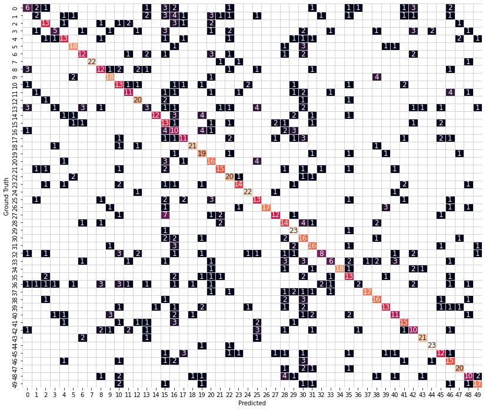

```python
from src.helpers import plot_confusion_matrix

plot_confusion_matrix(pred, truth)
```